# Identifying Good employees at risk of leaving

Yonatan Avivi, Hiroko Okamura, Jenny Phung, Youhee Shin

February 3, 2017

# Objective

The objective of this analytical report is to help companies identify good employees who are at risk of leaving the company. With this information, companies can allocate their finances and resources on in areas that can help in retaining good employees.

# Analysis Process

First, we will analyze and visualize the data to get a basic understanding of the data inhand (*Human Resources Analytics by Ludovic Benistant from kaggle.com*). After obtaining a basic understanding of the data, we will check the correlation of the factors to identify and interpret the key factors that drive employees to leave.

Second, we will segment the entire employees by using the cluster method to observe which cluster of employees have a higher possbility of leaving.

# 1. Data check and Visualisation

## 1.1 Load and Explore the data

First, let’s load the data to use.

```r
ProjectData <- read.csv("./data/HR_data.csv")
ProjectData = data.matrix(ProjectData)
```

1. Employee satisfaction level
2. Last evaluation
3. Number of projects
4. Average monthly hours
5. Time spent at the company
6. Whether they have had a work accident
7. Whether they have had a promotion in the last 5 years
8. Department
9. Salary (1=low, 2=medium, 3=high)
10. Whether employee has left

This is how the first 10 set of data (employees) look like.

|  | Obs.01 | Obs.02 | Obs.03 | Obs.04 | Obs.05 | Obs.06 | Obs.07 | Obs.08 | Obs.09 | Obs.10 |
| --- | --- | --- | --- | --- | --- | --- | --- | --- | --- | --- |
| satisfaction_level | 0.38 | 0.80 | 0.11 | 0.72 | 0.37 | 0.41 | 0.10 | 0.92 | 0.89 | 0.42 |
| last_evaluation | 0.53 | 0.86 | 0.88 | 0.87 | 0.52 | 0.50 | 0.77 | 0.85 | 1.00 | 0.53 |
| number_project | 2.00 | 5.00 | 7.00 | 5.00 | 2.00 | 2.00 | 6.00 | 5.00 | 5.00 | 2.00 |
| average_montly_hours | 157.00 | 262.00 | 272.00 | 223.00 | 159.00 | 153.00 | 247.00 | 259.00 | 224.00 | 142.00 |
| time_spend_company | 3.00 | 6.00 | 4.00 | 5.00 | 3.00 | 3.00 | 4.00 | 5.00 | 5.00 | 3.00 |
| Work_accident | 0.00 | 0.00 | 0.00 | 0.00 | 0.00 | 0.00 | 0.00 | 0.00 | 0.00 | 0.00 |
| left | 1.00 | 1.00 | 1.00 | 1.00 | 1.00 | 1.00 | 1.00 | 1.00 | 1.00 | 1.00 |
| promotion_last_5years | 0.00 | 0.00 | 0.00 | 0.00 | 0.00 | 0.00 | 0.00 | 0.00 | 0.00 | 0.00 |
| salary_level | 1.00 | 2.00 | 2.00 | 1.00 | 1.00 | 1.00 | 1.00 | 1.00 | 1.00 | 1.00 |
| sales | 1.00 | 1.00 | 1.00 | 1.00 | 1.00 | 1.00 | 1.00 | 1.00 | 1.00 | 1.00 |
| accounting | 0.00 | 0.00 | 0.00 | 0.00 | 0.00 | 0.00 | 0.00 | 0.00 | 0.00 | 0.00 |
| hr | 0.00 | 0.00 | 0.00 | 0.00 | 0.00 | 0.00 | 0.00 | 0.00 | 0.00 | 0.00 |
| technical | 0.00 | 0.00 | 0.00 | 0.00 | 0.00 | 0.00 | 0.00 | 0.00 | 0.00 | 0.00 |
| support | 0.00 | 0.00 | 0.00 | 0.00 | 0.00 | 0.00 | 0.00 | 0.00 | 0.00 | 0.00 |
| management | 0.00 | 0.00 | 0.00 | 0.00 | 0.00 | 0.00 | 0.00 | 0.00 | 0.00 | 0.00 |
| IT | 0.00 | 0.00 | 0.00 | 0.00 | 0.00 | 0.00 | 0.00 | 0.00 | 0.00 | 0.00 |
| product_mng | 0.00 | 0.00 | 0.00 | 0.00 | 0.00 | 0.00 | 0.00 | 0.00 | 0.00 | 0.00 |
| marketing | 0.00 | 0.00 | 0.00 | 0.00 | 0.00 | 0.00 | 0.00 | 0.00 | 0.00 | 0.00 |
| RandD | 0.00 | 0.00 | 0.00 | 0.00 | 0.00 | 0.00 | 0.00 | 0.00 | 0.00 | 0.00 |

The data we use here have the following descriptive statistics.

|  | min | 25 percent | median | mean | 75 percent | max | std |
| --- | --- | --- | --- | --- | --- | --- | --- |
| satisfaction_level | 0.09 | 0.44 | 0.64 | 0.61 | 0.82 | 1 | 0.25 |
| last_evaluation | 0.36 | 0.56 | 0.72 | 0.72 | 0.87 | 1 | 0.17 |
| number_project | 2.00 | 3.00 | 4.00 | 3.80 | 5.00 | 7 | 1.23 |
| average_montly_hours | 96.00 | 156.00 | 200.00 | 201.05 | 245.00 | 310 | 49.94 |
| time_spend_company | 2.00 | 3.00 | 3.00 | 3.50 | 4.00 | 10 | 1.46 |
| Work_accident | 0.00 | 0.00 | 0.00 | 0.14 | 0.00 | 1 | 0.35 |
| left | 0.00 | 0.00 | 0.00 | 0.24 | 0.00 | 1 | 0.43 |
| promotion_last_5years | 0.00 | 0.00 | 0.00 | 0.02 | 0.00 | 1 | 0.14 |
| salary_level | 1.00 | 1.00 | 2.00 | 1.59 | 2.00 | 3 | 0.64 |
| sales | 0.00 | 0.00 | 0.00 | 0.28 | 1.00 | 1 | 0.45 |
| accounting | 0.00 | 0.00 | 0.00 | 0.05 | 0.00 | 1 | 0.22 |
| hr | 0.00 | 0.00 | 0.00 | 0.05 | 0.00 | 1 | 0.22 |
| technical | 0.00 | 0.00 | 0.00 | 0.18 | 0.00 | 1 | 0.39 |
| support | 0.00 | 0.00 | 0.00 | 0.15 | 0.00 | 1 | 0.36 |
| management | 0.00 | 0.00 | 0.00 | 0.04 | 0.00 | 1 | 0.20 |
| IT | 0.00 | 0.00 | 0.00 | 0.08 | 0.00 | 1 | 0.27 |
| product_mng | 0.00 | 0.00 | 0.00 | 0.06 | 0.00 | 1 | 0.24 |
| marketing | 0.00 | 0.00 | 0.00 | 0.06 | 0.00 | 1 | 0.23 |
| RandD | 0.00 | 0.00 | 0.00 | 0.05 | 0.00 | 1 | 0.22 |

## 1.2 Scale the data

Here, we are standardizing the data in order to avoid having the problem of the result being driven by a few relatively large values. We will scale the data between 0 and 1.

```r
ProjectDataFactor_scaled = apply(ProjectDataFactor, 2, function(r) {
    res = (r - min(r))/(max(r) - min(r))
    res
})
```

Below is the summary statistics of the scaled dataset.

|  | min | 25 percent | median | mean | 75 percent | max | std |
| --- | --- | --- | --- | --- | --- | --- | --- |
| satisfaction_level | 0 | 0.38 | 0.60 | 0.57 | 0.80 | 1 | 0.27 |
| last_evaluation | 0 | 0.31 | 0.56 | 0.56 | 0.80 | 1 | 0.27 |
| number_project | 0 | 0.20 | 0.40 | 0.36 | 0.60 | 1 | 0.25 |
| average_montly_hours | 0 | 0.28 | 0.49 | 0.49 | 0.70 | 1 | 0.23 |
| time_spend_company | 0 | 0.12 | 0.12 | 0.19 | 0.25 | 1 | 0.18 |
| Work_accident | 0 | 0.00 | 0.00 | 0.14 | 0.00 | 1 | 0.35 |
| left | 0 | 0.00 | 0.00 | 0.24 | 0.00 | 1 | 0.43 |
| promotion_last_5years | 0 | 0.00 | 0.00 | 0.02 | 0.00 | 1 | 0.14 |
| salary_level | 0 | 0.00 | 0.50 | 0.30 | 0.50 | 1 | 0.32 |
| sales | 0 | 0.00 | 0.00 | 0.28 | 1.00 | 1 | 0.45 |
| accounting | 0 | 0.00 | 0.00 | 0.05 | 0.00 | 1 | 0.22 |
| hr | 0 | 0.00 | 0.00 | 0.05 | 0.00 | 1 | 0.22 |
| technical | 0 | 0.00 | 0.00 | 0.18 | 0.00 | 1 | 0.39 |
| support | 0 | 0.00 | 0.00 | 0.15 | 0.00 | 1 | 0.36 |
| management | 0 | 0.00 | 0.00 | 0.04 | 0.00 | 1 | 0.20 |
| IT | 0 | 0.00 | 0.00 | 0.08 | 0.00 | 1 | 0.27 |
| product_mng | 0 | 0.00 | 0.00 | 0.06 | 0.00 | 1 | 0.24 |
| marketing | 0 | 0.00 | 0.00 | 0.06 | 0.00 | 1 | 0.23 |
| RandD | 0 | 0.00 | 0.00 | 0.05 | 0.00 | 1 | 0.22 |

## 1.3 Check Correlations

The simplest way to have a first look at a dataset is to check the correlation. By doing this, we can easily see which factors have a high positive/negative correlation with leaving employees. This is different from a causality, therefore we cannot conclude that a highly correlated factor (independent variables) leads an employee to leave (dependent variable). Also, if some of the factors (independent variables) are highly correlated with each other, we could also consider to group these attributes together.

|  | satisfaction_level | last_evaluation | number_project | average_montly_hours | time_spend_company | Work_accident | left | promotion_last_5years | salary_level | sales | accounting | hr | technical | support | management | IT | product_mng | marketing | RandD |
| --- | --- | --- | --- | --- | --- | --- | --- | --- | --- | --- | --- | --- | --- | --- | --- | --- | --- | --- | --- |
| satisfaction_level | 1.00 | 0.11 | -0.14 | -0.02 | -0.10 | 0.06 | -0.39 | 0.03 | 0.05 | 0.00 | -0.03 | -0.01 | -0.01 | 0.01 | 0.01 | 0.01 | 0.01 | 0.01 | 0.01 |
| last_evaluation | 0.11 | 1.00 | 0.35 | 0.34 | 0.13 | -0.01 | 0.01 | -0.01 | -0.01 | -0.02 | 0.00 | -0.01 | 0.01 | 0.02 | 0.01 | 0.00 | 0.00 | 0.00 | -0.01 |
| number_project | -0.14 | 0.35 | 1.00 | 0.42 | 0.20 | 0.00 | 0.02 | -0.01 | 0.00 | -0.01 | 0.00 | -0.03 | 0.03 | 0.00 | 0.01 | 0.00 | 0.00 | -0.02 | 0.01 |
| average_montly_hours | -0.02 | 0.34 | 0.42 | 1.00 | 0.13 | -0.01 | 0.07 | 0.00 | 0.00 | 0.00 | 0.00 | -0.01 | 0.01 | 0.00 | 0.00 | 0.01 | -0.01 | -0.01 | 0.00 |
| time_spend_company | -0.10 | 0.13 | 0.20 | 0.13 | 1.00 | 0.00 | 0.14 | 0.07 | 0.05 | 0.02 | 0.00 | -0.02 | -0.03 | -0.03 | 0.12 | -0.01 | 0.00 | 0.01 | -0.02 |
| Work_accident | 0.06 | -0.01 | 0.00 | -0.01 | 0.00 | 1.00 | -0.15 | 0.04 | 0.01 | 0.00 | -0.01 | -0.02 | -0.01 | 0.01 | 0.01 | -0.01 | 0.00 | 0.01 | 0.02 |
| left | -0.39 | 0.01 | 0.02 | 0.07 | 0.14 | -0.15 | 1.00 | -0.06 | -0.16 | 0.01 | 0.02 | 0.03 | 0.02 | 0.01 | -0.05 | -0.01 | -0.01 | 0.00 | -0.05 |
| promotion_last_5years | 0.03 | -0.01 | -0.01 | 0.00 | 0.07 | 0.04 | -0.06 | 1.00 | 0.10 | 0.01 | 0.00 | 0.00 | -0.04 | -0.04 | 0.13 | -0.04 | -0.04 | 0.05 | 0.02 |
| salary_level | 0.05 | -0.01 | 0.00 | 0.00 | 0.05 | 0.01 | -0.16 | 0.10 | 1.00 | -0.04 | 0.01 | 0.00 | -0.02 | -0.03 | 0.16 | -0.01 | -0.01 | 0.01 | 0.00 |
| sales | 0.00 | -0.02 | -0.01 | 0.00 | 0.02 | 0.00 | 0.01 | 0.01 | -0.04 | 1.00 | -0.14 | -0.14 | -0.29 | -0.26 | -0.13 | -0.18 | -0.16 | -0.15 | -0.15 |
| accounting | -0.03 | 0.00 | 0.00 | 0.00 | 0.00 | -0.01 | 0.02 | 0.00 | 0.01 | -0.14 | 1.00 | -0.05 | -0.11 | -0.10 | -0.05 | -0.07 | -0.06 | -0.06 | -0.05 |
| hr | -0.01 | -0.01 | -0.03 | -0.01 | -0.02 | -0.02 | 0.03 | 0.00 | 0.00 | -0.14 | -0.05 | 1.00 | -0.11 | -0.10 | -0.05 | -0.07 | -0.06 | -0.06 | -0.05 |
| technical | -0.01 | 0.01 | 0.03 | 0.01 | -0.03 | -0.01 | 0.02 | -0.04 | -0.02 | -0.29 | -0.11 | -0.11 | 1.00 | -0.20 | -0.10 | -0.14 | -0.12 | -0.12 | -0.11 |
| support | 0.01 | 0.02 | 0.00 | 0.00 | -0.03 | 0.01 | 0.01 | -0.04 | -0.03 | -0.26 | -0.10 | -0.10 | -0.20 | 1.00 | -0.09 | -0.12 | -0.11 | -0.10 | -0.10 |
| management | 0.01 | 0.01 | 0.01 | 0.00 | 0.12 | 0.01 | -0.05 | 0.13 | 0.16 | -0.13 | -0.05 | -0.05 | -0.10 | -0.09 | 1.00 | -0.06 | -0.05 | -0.05 | -0.05 |
| IT | 0.01 | 0.00 | 0.00 | 0.01 | -0.01 | -0.01 | -0.01 | -0.04 | -0.01 | -0.18 | -0.07 | -0.07 | -0.14 | -0.12 | -0.06 | 1.00 | -0.08 | -0.07 | -0.07 |
| product_mng | 0.01 | 0.00 | 0.00 | -0.01 | 0.00 | 0.00 | -0.01 | -0.04 | -0.01 | -0.16 | -0.06 | -0.06 | -0.12 | -0.11 | -0.05 | -0.08 | 1.00 | -0.06 | -0.06 |
| marketing | 0.01 | 0.00 | -0.02 | -0.01 | 0.01 | 0.01 | 0.00 | 0.05 | 0.01 | -0.15 | -0.06 | -0.06 | -0.12 | -0.10 | -0.05 | -0.07 | -0.06 | 1.00 | -0.06 |
| RandD | 0.01 | -0.01 | 0.01 | 0.00 | -0.02 | 0.02 | -0.05 | 0.02 | 0.00 | -0.15 | -0.05 | -0.05 | -0.11 | -0.10 | -0.05 | -0.07 | -0.06 | -0.06 | 1.00 |

# 2. Cluster Analysis and Segmentation

## 2.1 (1st try) Select segmentation variables and methods

We use all the variables except “Whether the employee has left.” We use Euclidean distance.

```r
segmentation_attributes_used = c(1:6, 8:19)
profile_attributes_used = c(1:19)
numb_clusters_used = 5
profile_with = "hclust"
distance_used = "euclidean"
hclust_method = "ward.D"
```

Here are the differences between the observations using the distance metric we selected:

|  | Obs.01 | Obs.02 | Obs.03 | Obs.04 | Obs.05 | Obs.06 | Obs.07 | Obs.08 | Obs.09 | Obs.10 |
| --- | --- | --- | --- | --- | --- | --- | --- | --- | --- | --- |
| Obs.01 | 0.00 |  |  |  |  |  |  |  |  |  |
| Obs.02 | 1.21 | 0.00 |  |  |  |  |  |  |  |  |
| Obs.03 | 1.39 | 0.89 | 0.00 |  |  |  |  |  |  |  |
| Obs.04 | 0.97 | 0.55 | 0.96 | 0.00 |  |  |  |  |  |  |
| Obs.05 | 0.02 | 1.22 | 1.39 | 0.98 | 0.00 |  |  |  |  |  |
| Obs.06 | 0.06 | 1.23 | 1.43 | 0.99 | 0.06 | 0.00 |  |  |  |  |
| Obs.07 | 1.03 | 0.98 | 0.58 | 0.75 | 1.03 | 1.07 | 0.00 |  |  |  |
| Obs.08 | 1.12 | 0.53 | 1.11 | 0.28 | 1.13 | 1.13 | 0.94 | 0.00 |  |  |
| Obs.09 | 1.17 | 0.60 | 1.12 | 0.28 | 1.18 | 1.19 | 0.97 | 0.29 | 0.00 |  |
| Obs.10 | 0.08 | 1.23 | 1.43 | 0.98 | 0.10 | 0.07 | 1.08 | 1.13 | 1.17 | 0 |

## 2.2 (1st try) Visualize Pair-wise Distances

We can see the histogram of, say, the first 2 variables.

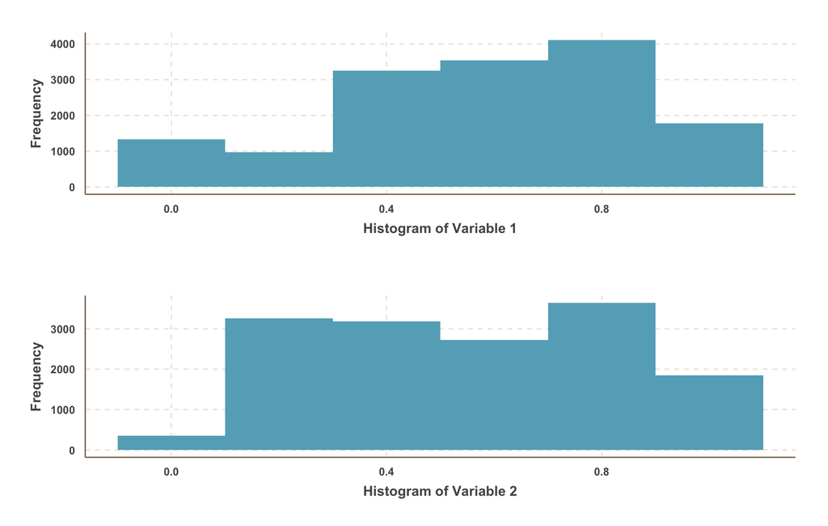

or the histogram of all pairwise distances for the euclidean distance:

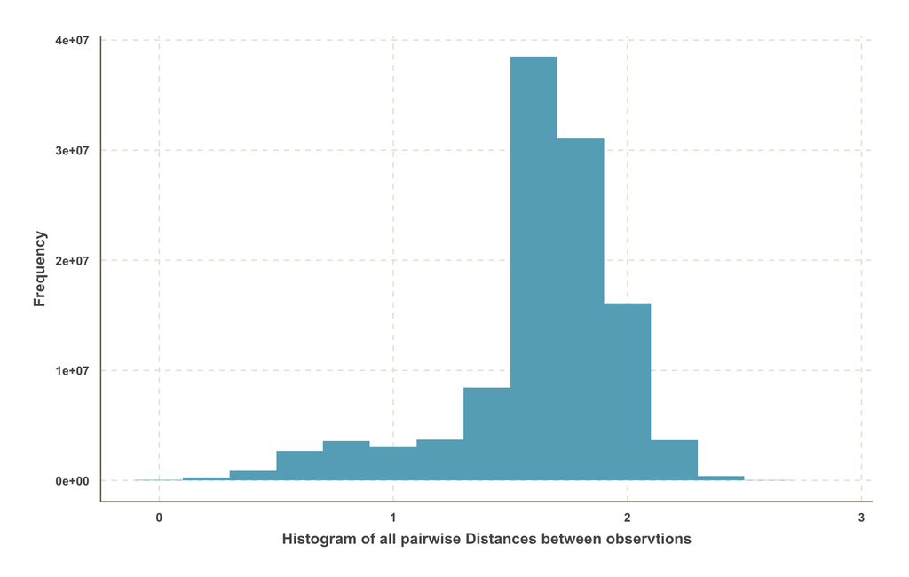

## 2.3 (1st try) Number of Segments

Let’s use Hierarchical Clustering methods. It may be useful to see the dendrogram from, to have a quick idea of how the data may be segmented and how many segments there may be. Here is the dendrogram for our data:

[interactive chart not shown]

We can also plot the “distances” traveled before we need to merge any of the lower and smaller in size clusters into larger ones - the heights of the tree branches that link the clusters as we traverse the tree from its leaves to its root. If we have n observations, this plot has n-1 numbers, we see the first 20 here.

[interactive chart not shown]

| Observation Number | Cluster_Membership |
| --- | --- |
| 1 | 1 |
| 2 | 1 |
| 3 | 1 |
| 4 | 1 |
| 5 | 1 |
| 6 | 1 |
| 7 | 1 |
| 8 | 1 |
| 9 | 1 |
| 10 | 1 |
| 11 | 1 |
| 12 | 1 |
| 13 | 1 |
| 14 | 1 |
| 15 | 1 |
| 16 | 1 |
| 17 | 1 |
| 18 | 1 |
| 19 | 2 |
| 20 | 1 |

## 2.4 (1st try) Profile and interpret the segments

Having decided how many clusters to use, we would like to get a better understanding of who the customers in those clusters are and interpret the segments.

Let’s see first how many observations we have in each segment, for the segments we selected above:

[output not shown]

The average values of our data for the total population as well as within each customer segment are:

|  | Population | Segment 1 | Segment 2 | Segment 3 | Segment 4 |
| --- | --- | --- | --- | --- | --- |
| satisfaction_level | 0.57 | 0.57 | 0.58 | 0.57 | 0.58 |
| last_evaluation | 0.56 | 0.55 | 0.56 | 0.56 | 0.57 |
| number_project | 0.36 | 0.36 | 0.36 | 0.38 | 0.36 |
| average_montly_hours | 0.49 | 0.49 | 0.49 | 0.50 | 0.49 |
| time_spend_company | 0.19 | 0.19 | 0.19 | 0.18 | 0.17 |
| Work_accident | 0.14 | 0.14 | 0.15 | 0.14 | 0.15 |
| left | 0.24 | 0.25 | 0.22 | 0.26 | 0.25 |
| promotion_last_5years | 0.02 | 0.00 | 0.05 | 0.00 | 0.00 |
| salary_level | 0.30 | 0.27 | 0.33 | 0.28 | 0.27 |
| sales | 0.28 | 1.00 | 0.02 | 0.00 | 0.00 |
| accounting | 0.05 | 0.00 | 0.13 | 0.00 | 0.00 |
| hr | 0.05 | 0.00 | 0.12 | 0.00 | 0.00 |
| technical | 0.18 | 0.00 | 0.00 | 1.00 | 0.00 |
| support | 0.15 | 0.00 | 0.00 | 0.00 | 1.00 |
| management | 0.04 | 0.00 | 0.10 | 0.00 | 0.00 |
| IT | 0.08 | 0.00 | 0.20 | 0.00 | 0.00 |
| product_mng | 0.06 | 0.00 | 0.15 | 0.00 | 0.00 |
| marketing | 0.06 | 0.00 | 0.14 | 0.00 | 0.00 |
| RandD | 0.05 | 0.00 | 0.13 | 0.00 | 0.00 |

The segment profile looks to depend too much on department. Let’s try the analysis again excluding department information.

## 2.1 (2nd try) Select segmentation variables and methods

We use all the variables except “Whether the employee has left.” and department. We use Euclidean distance.

```r
segmentation_attributes_used = c(1:6, 8:9)
profile_attributes_used = c(1:19)
numb_clusters_used = 5
profile_with = "hclust"
distance_used = "euclidean"
hclust_method = "ward.D"
```

## 2.2 (2nd try) Visualize Pair-wise Distances

Let us skip this subsection for the 2nd try.

## 2.3 (2nd try) Number of Segments

Let’s plot the “distances” traveled before we need to merge any of the lower and smaller in size clusters into larger ones.

[interactive chart not shown]

For now let’s consider the 5-segments solution. We can also see the segment each observation (respondent in this case) belongs to for the first 20 people:

| Observation Number | Cluster_Membership |
| --- | --- |
| 1 | 1 |
| 2 | 2 |
| 3 | 3 |
| 4 | 4 |
| 5 | 1 |
| 6 | 1 |
| 7 | 3 |
| 8 | 4 |
| 9 | 4 |
| 10 | 1 |
| 11 | 1 |
| 12 | 3 |
| 13 | 4 |
| 14 | 1 |
| 15 | 1 |
| 16 | 1 |
| 17 | 1 |
| 18 | 4 |
| 19 | 3 |
| 20 | 4 |

## 2.4 (2nd try) Profile and interpret the segments

Having decided how many clusters to use, we would like to get a better understanding of who the customers in those clusters are and interpret the segments.

Let’s see first how many observations we have in each segment, for the segments we selected above:

|  | Segment 1 | Segment 2 | Segment 3 | Segment 4 | Segment 5 |
| --- | --- | --- | --- | --- | --- |
| Number of Obs. | 1816 | 4172 | 2728 | 4190 | 2093 |

The average values of our data for the total population as well as within each customer segment are:

|  | Population | Segment 1 | Segment 2 | Segment 3 | Segment 4 | Segment 5 |
| --- | --- | --- | --- | --- | --- | --- |
| satisfaction_level | 0.57 | 0.37 | 0.71 | 0.28 | 0.70 | 0.61 |
| last_evaluation | 0.56 | 0.26 | 0.60 | 0.61 | 0.61 | 0.55 |
| number_project | 0.36 | 0.04 | 0.37 | 0.57 | 0.36 | 0.36 |
| average_montly_hours | 0.49 | 0.24 | 0.51 | 0.60 | 0.51 | 0.48 |
| time_spend_company | 0.19 | 0.12 | 0.14 | 0.36 | 0.16 | 0.19 |
| Work_accident | 0.14 | 0.00 | 0.00 | 0.03 | 0.00 | 1.00 |
| left | 0.24 | 0.77 | 0.10 | 0.35 | 0.15 | 0.08 |
| promotion_last_5years | 0.02 | 0.00 | 0.00 | 0.12 | 0.00 | 0.00 |
| salary_level | 0.30 | 0.25 | 0.60 | 0.33 | 0.00 | 0.30 |
| sales | 0.28 | 0.29 | 0.25 | 0.29 | 0.29 | 0.27 |
| accounting | 0.05 | 0.06 | 0.05 | 0.06 | 0.05 | 0.05 |
| hr | 0.05 | 0.07 | 0.05 | 0.05 | 0.05 | 0.04 |
| technical | 0.18 | 0.17 | 0.18 | 0.18 | 0.19 | 0.18 |
| support | 0.15 | 0.16 | 0.16 | 0.12 | 0.15 | 0.16 |
| management | 0.04 | 0.03 | 0.05 | 0.07 | 0.02 | 0.04 |
| IT | 0.08 | 0.07 | 0.09 | 0.07 | 0.09 | 0.08 |
| product_mng | 0.06 | 0.06 | 0.06 | 0.05 | 0.07 | 0.06 |
| marketing | 0.06 | 0.06 | 0.06 | 0.06 | 0.05 | 0.06 |
| RandD | 0.05 | 0.04 | 0.06 | 0.05 | 0.05 | 0.06 |

Everyone in the Segment 5 had work accident, which does not look good segmentations. Let’s try the analysis again excluding work accident information.

## 2.1 (3rd try) Select segmentation variables and methods

We use all the variables except “Whether the employee has left,” department, and work accident. We use Euclidean distance.

```r
segmentation_attributes_used = c(1:5, 8:9)
profile_attributes_used = c(1:19)
numb_clusters_used = 4
profile_with = "hclust"
distance_used = "euclidean"
hclust_method = "ward.D"
```

## 2.2 (3rd try) Visualize Pair-wise Distances

Let us skip this subsection for the 3rd try.

## 2.3 (3rd try) Number of Segments

Let’s plot the “distances” traveled before we need to merge any of the lower and smaller in size clusters into larger ones.

[interactive chart not shown]

For now let’s consider the 4-segments solution. We can also see the segment each observation (respondent in this case) belongs to for the first 20 people:

| Observation Number | Cluster_Membership |
| --- | --- |
| 1 | 1 |
| 2 | 2 |
| 3 | 3 |
| 4 | 4 |
| 5 | 1 |
| 6 | 1 |
| 7 | 3 |
| 8 | 4 |
| 9 | 4 |
| 10 | 1 |
| 11 | 1 |
| 12 | 3 |
| 13 | 4 |
| 14 | 1 |
| 15 | 1 |
| 16 | 1 |
| 17 | 1 |
| 18 | 4 |
| 19 | 2 |
| 20 | 4 |

## 2.4 (3rd try) Profile and interpret the segments

Having decided how many clusters to use, we would like to get a better understanding of who the customers in those clusters are and interpret the segments.

Let’s see first how many observations we have in each segment, for the segments we selected above:

|  | Segment 1 | Segment 2 | Segment 3 | Segment 4 |
| --- | --- | --- | --- | --- |
| Number of Obs. | 1930 | 6017 | 2135 | 4917 |

The average values of our data for the total population as well as within each customer segment are:

|  | Population | Segment 1 | Segment 2 | Segment 3 | Segment 4 |
| --- | --- | --- | --- | --- | --- |
| satisfaction_level | 0.57 | 0.37 | 0.70 | 0.12 | 0.70 |
| last_evaluation | 0.56 | 0.26 | 0.58 | 0.67 | 0.59 |
| number_project | 0.36 | 0.04 | 0.36 | 0.65 | 0.36 |
| average_montly_hours | 0.49 | 0.24 | 0.50 | 0.65 | 0.51 |
| time_spend_company | 0.19 | 0.12 | 0.20 | 0.29 | 0.15 |
| Work_accident | 0.14 | 0.08 | 0.17 | 0.12 | 0.16 |
| left | 0.24 | 0.76 | 0.08 | 0.47 | 0.13 |
| promotion_last_5years | 0.02 | 0.00 | 0.05 | 0.00 | 0.00 |
| salary_level | 0.30 | 0.26 | 0.57 | 0.26 | 0.00 |
| sales | 0.28 | 0.30 | 0.27 | 0.27 | 0.28 |
| accounting | 0.05 | 0.06 | 0.05 | 0.06 | 0.05 |
| hr | 0.05 | 0.07 | 0.04 | 0.05 | 0.05 |
| technical | 0.18 | 0.17 | 0.17 | 0.19 | 0.19 |
| support | 0.15 | 0.15 | 0.15 | 0.14 | 0.15 |
| management | 0.04 | 0.02 | 0.06 | 0.04 | 0.02 |
| IT | 0.08 | 0.07 | 0.08 | 0.08 | 0.08 |
| product_mng | 0.06 | 0.06 | 0.06 | 0.05 | 0.07 |
| marketing | 0.06 | 0.06 | 0.06 | 0.05 | 0.05 |
| RandD | 0.05 | 0.04 | 0.05 | 0.05 | 0.06 |